[output not shown]

# Introduction

Many animal species have demonstrated the ability to quantify objects in their environment, including bees [@Dacke.Srinivasan.2008], fish [@Agrillo.etal.2008; @Agrillo.Dadda.2007;@Agrillo.etal.2011], amphibians [@Uller.etal.2003], birds [@Xia.etal.2001;@Emmerton.Renner.2006;@Emmerton.Renner.2009], and mammals [@Vonk.Beran.2012; @Nieder.2018;@Call.2000;@Beran.2001]. Quantification skills have strong adaptive value for survival and reproduction [@Nieder.2018], playing a role in navigation, predator avoidance, territory defense, foraging, courtship, mating, and avoiding brood parasitism [@White.etal.2009;@Carazo.etal.2012;@Arak.1983;@Nieder.2020;@Agrillo.etal.2017;@Yang.Chiao.2016]. Yet it remains unclear if the same cognitive processes apply across these different adaptive problems.

One of the key cognitive processes proposed for quantification is the *approximate number system*, which involves the approximate estimation of numerical quantity without relying on language or symbols [@Feigenson.etal.2004;@Nieder.2020]. The approximate number system is characterized by the numerical magnitude effect and the numerical distance effect [@Ditz.Nieder.2016;@Dehaene.etal.1998]. The *numerical magnitude effect* asserts that, at a given numerical difference (i.e., the mathematical difference between two numbers: 4-2 has a difference of 2), discrimination worsens with increasing magnitude, which is equivalent to a decreasing numerical ratio (the mathematical quotient between two numbers: 2/4 has a ratio of 0.5). Essentially, discrimination becomes more difficult as the numerical ratio approaches 1. The *numerical distance effect* asserts that discrimination improves with increasing numerical difference between two values. Essentially, discrimination becomes easier as the options become more dissimilar. Taken together, these two effects describe Weber’s Law [@Nieder.2020], which indicates the use of approximate amounts rather than precise numbers.

Animals are sensitive to quantification across a range of object types. [@Agrillo.Beran.2013;@Agrillo.Bisazza.2014]. Most of these numerical discrimination tasks use food as quantifiable objects [@Call.2000;@Beran.2001;@Kelly.2016;@Scarf.etal.2011;@Rugani.etal.2013]. In line with the numerical magnitude effect, accuracy in food quantity discrimination decreases as the ratio between the values approached 1 [@Ditz.Nieder.2016;@Cantlon.Brannon.2006; @Merten.Nieder.2009;@Hanus.Call.2007;@Evans.etal.2009]. Similarly, the numerical distance effect has been confirmed when animals discriminate food quantities better when there are larger numerical differences [@Ditz.Nieder.2016;@Kelly.2016;@Tornick.etal.2015;@Ditz.Nieder.2015].

In addition to food, some studies have used numbers of conspecifics to assess quantification [@Buckingham.etal.2007;@Agrillo.etal.2008;@Gomez-Laplaza.Gerlai.2016]. Many species prefer to be in larger groups, presumably because this dilutes their probability of being captured by predators [@Krause.Ruxton.2002;@Silk.etal.2014]. Though some studies show an effect of both difference and ratio on social quantity preference [@Agrillo.Dadda.2007;@Agrillo.etal.2008], others only show an effect of ratio [@Buckingham.etal.2007;@Gomez-Laplaza.Gerlai.2011]. While research shows ratio and difference effects on quantification in different types of objects (food and conspecifics), little research has examined these within a single test population.

The primary aim of the present study was to investigate how pinyon jays (*Gymnorhinus cyanocephalus*) use quantity information, specifically numerical difference and ratio, to choose between different quantities of food items or conspecifics. To address this aim, we offered pinyon jays a series of choices between smaller and larger numbers of items: either food or conspecifics. Our first hypothesis (H1) posits that pinyon jays will, on average, prefer larger over smaller numbers of food items and conspecifics. Our second hypothesis (H2) posits that pinyon jays will prefer more items more when the quantities have higher numerical differences and lower numerical ratios. Our third hypothesis (H3) posits that both numerical difference and ratio will influence preference independently of each other. This distinction is important because difference and ratio are highly correlated: as difference increases, ratio decreases. Testing these hypotheses in two different object types investigates whether the same cognitive processes generalize across adaptive problems faced by animals.

# Methods

We conducted both a food experiment and a social experiment to investigate quantification of food and conspecifics. Each experiment was replicated with the opposite set of birds so most birds saw both the food and social condition.

## Subjects

Replicate 1: Eight pinyon jays (1 female) completed all rounds of the food experiment and 10 jays (4 female) completed all rounds of the social experiment. A further 17 jays (6 female) from the colony were used as stooge conspecifics in the social experiment. Two jays were dropped from the social experiment due to unrelated health concerns.

Replicate 2: Four pinyon jays (1 female) completed all rounds of the food experiment and 10 jays (1 female) completed all rounds of the social experiment. A further 12 jays (5 female) from the colony were used as stooge conspecifics in the social experiment.

The jays in the food item experiment were housed two to a double cage, while the jays in the social experiment were individually housed. The subjects were not food restricted in either experiment.

## Food Experiment

### Experimental Procedure

At the beginning of each trial, the experimenter placed the appropriate number of mealworms in each of the dishes. The subject hopped forward to one of the front perches to signal choice. The experimenter then removed the opposite dish and the subject had up to three minutes to consume the mealworms. Once the subject consumed all mealworms, the next trial began. If the subject did not make a choice and/or did not finish all mealworms within three minutes, the session stopped.

Each bird experienced 10 repetitions for each of the 15 numerical pairs between 1 and 6 (e.g., 6 vs 5, 6 vs 4, 6 vs 3, etc.). The side of the larger option was pseudo-randomized with no left or right runs longer than three in a row. Subjects ran in a randomized order each day. Birds averaged 3 trials per session.

## Social Experiment

### Apparatus

The apparatus was a Y maze where the subject entered a large chamber at the base of the maze and could choose one of two arms. Guillotine style doors separated the entrance chamber from the arms where a large bird cage housing the stooge birds was placed.

### Experimental Procedure

The experimenter held the subject inside the apparatus and showed them each option for six seconds before releasing them into the entrance chamber. Once the subject crossed the threshold of one of the doors, *both* doors were gently closed. After three minutes elapsed, the handler collected the subject and returned them to their home cage. These steps repeated until all birds had run through the experiment.

Each subject experienced five trials (replicate 1) or ten trials (replicate 2) for each of the numerical pairs between 1 and 6 (e.g., 6 vs 5, 6 vs 4, 6 vs 3, etc.). The side of the larger option was pseudo-randomized with no left or right runs longer than three consecutive trials. The pairs were organized into blocks with one instance of each pair per block and pairs randomized within each block. Subjects ran in a randomized order each day.

## Data Analysis

To test our second and third hypotheses, whether numerical difference and ratio predict preferences between smaller and larger options independently, we used generalized linear mixed-effects modeling. We used trial-level choices for either the larger (coded as 1) or smaller (coded as 0) option available in the number pair as the response variable. To investigate our hypotheses, we used model selection to compare which combination of random (subject, pair, or both) and fixed (ratio, difference, or a combination of both) effects best describe each data set (food and social). We draw inferences based on Bayesian statistics (*BF* values) where a *BF* > 3 is sufficient evidence for the alternative hypothesis, *BF* < 1/3 is sufficient evidence for the null hypothesis, and 1/3 < *BF* < 3 indicate neither hypothesis has evidence supporting it (suggesting the sample size is too small to draw conclusions).

# Results

## Food Experiment

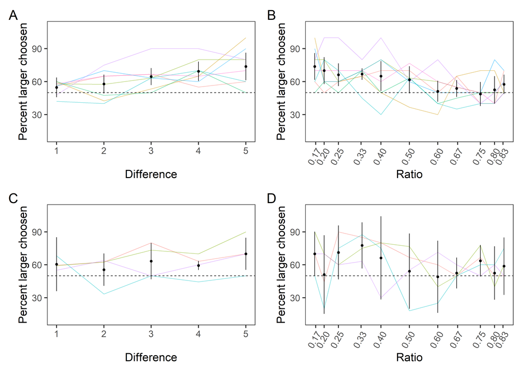

```r
include_graphics(here("figures/food_figure.png"))
```

## Social Experiment

Hypothesis 1 predicted that subjects would choose the larger number of flock mates over the smaller. One sample t-tests provided moderate evidence that our hypothesis was supported during the first replicate ($M = 55.33$, 95% CI $[52.34, 58.32]$, $t(9) = 4.03$, $p = .003$, $\mathrm{BF}_{\textrm{10}} = 16.67$). However, evidence supported no difference from chance in the second replicate ($M = 50.19$, 95% CI $[47.06, 53.32]$, $t(9) = 0.13$, $p = .896$, $\mathrm{BF}_{\textrm{10}} = 0.31$). This is the only incongruency between the replicates. The slight preference for the larger side is likely not a true preference for larger *amounts* but rather a preferred partner is more likely to appear in the larger group. To account for this, we completed 10 replications of each pair instead of 5 in replication 2.

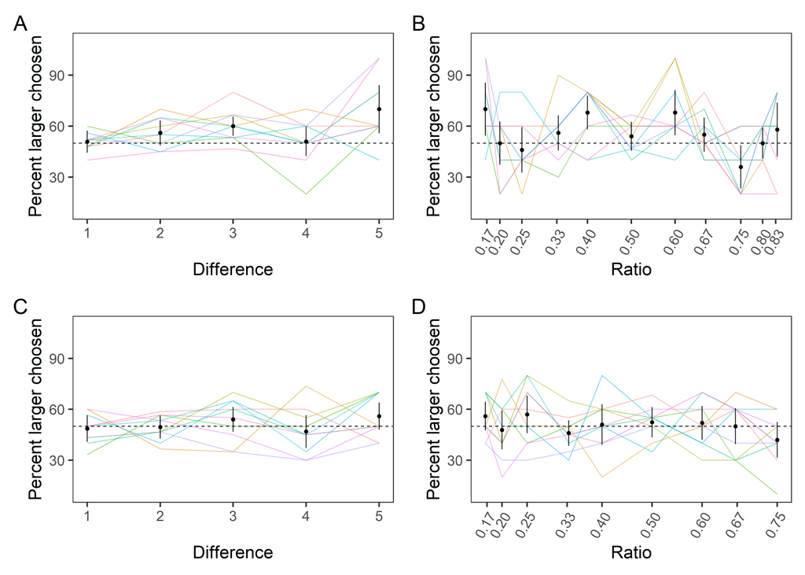

```r
include_graphics(here("figures/social_figure.png"))
```

# Discussion

We examined pinyon jays’ quantitative abilities in choosing between different numbers of food items and social partners. Over all numerical pairs, birds chose the larger of the two options in the food experiment but not in the social experiment, partially confirming our first hypothesis. In the food study, smaller numerical ratios but not larger numerical differences predicted the birds’ choices, partially confirming our second hypothesis. In the social experiment, neither ratio nor difference predicted choice, contradicting our second hypothesis. In both the food and social experiments, difference and ratio did not independently predict choice, contradicting our third hypothesis.

In the food study, our pinyon jays preferred larger over smaller quantities more as the numerical ratios decrease, which aligns with previous corvid research demonstrating a numerical magnitude effect [@Ditz.Nieder.2016;@Kelly.2016;@Tornick.etal.2015]. This provides evidence for pinyon jays using the approximate number system as a mechanism for quantification. However, unlike the previous corvid studies, we did not find the numerical distance effect, as number preference did not depend on the difference between two values.

Our study design does not allow us to pinpoint the exact features by which the birds make these quantitative choices. For the food preference tasks, the birds may choose larger *numbers* of food items or larger *amounts* of them. Using number involves tracking the quantity of individuated objects. However, in many cases, animals choose based on amount, which refers to other measures or proxies of quantity such as item size, surface area, volume, perimeter, and density [@Menzel.1960; @Uller.etal.2003; @Stevens.etal.2007; @Gomez-Laplaza.etal.2019]. It is possible that our jays used, for example, surface area to choose their food items. This is a reasonable criteria because surface area may be a better proxy of total calories than absolute number (i.e., two large mealworms my provide more calories than three small mealworms). Future work is needed to tease apart which features birds use to make quantitative decisions.

## Conclusion

This research investigated how pinyon jays assess numbers of food items and conspecifics in preference tasks. For food items, numerical ratio predicted their choices, but neither ratio nor difference predicted choices in the social preferences task. Though quantity is important for selecting food items, other factors such as flock mate identity may be more important for selecting social groups to join. Thus, in quantification situations, the type of objects to be quantified can drive the cognitive strategies that animals use. Numerical Cognition research in non-human animals is lacking in non-food based tasks and should be further explored.

## Acknowledgments

This research was funded by National Science Foundation grants (NSF-1062045, NSF-1658837). We would like to thank Kylie Hughes, Toria Biancalana, Hailey Wilson, Bailey Wilson, Isaac Martinez, and Rachel Bruner for helping run the experiments and caring for our birds.